# 6일차

## 결론

- 지금까지 각 컬럼들의 의미를 부여하지 않았음
- 이후에 도메인 지식을 이용해 분석을 이어가야 함
- 생소한 데이터를 마주했을 때 컬럼의 의미를 부여하지 않고도 분석하는 방향과 방법을 이해

## PDP(부분의존도)

- one way pdp
- two way pdp

```
<sklearn.inspection._plot.partial_dependence.PartialDependenceDisplay at 0x24841db5400>
```

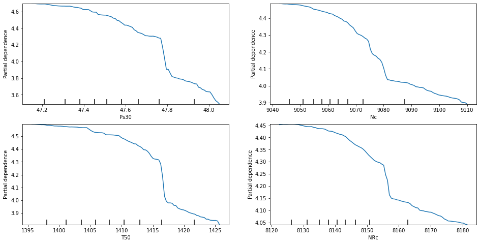

```python
# one way pdp
from sklearn.inspection import plot_partial_dependence as pdp

fig, ((ax1, ax2), (ax3, ax4)) = plt.subplots(ncols=2, nrows=2)
fig.set_size_inches(16, 8)

model = rf(n_estimators  = int(121.30078559138387),
           max_depth = int(13.390414831657525),
           max_features = 0.34971236824977475,
           min_samples_split = 1.0000000000000006e-10,
           min_samples_leaf = 1.0000000000000006e-10 / 2,
           n_jobs=-1)

model.fit(X_train, y_train)
pdp(model, X, ['Ps30'], ax=ax1)
pdp(model, X, ['Nc'], ax=ax2)
pdp(model, X, ['T50'], ax=ax3)
pdp(model, X, ['NRc'], ax=ax4)

# Ps30이 커질수록 낮아지는 경향이 있는데,
# 기울기가 일정하지 않음(한 번에 대폭 감소하는 구간이 있음)
```

```
<sklearn.inspection._plot.partial_dependence.PartialDependenceDisplay at 0x2484311cc10>
```

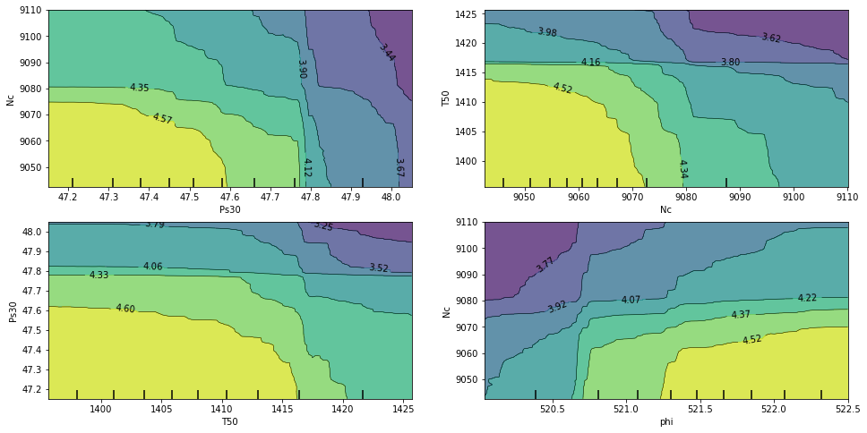

```python
fig, ((ax1, ax2), (ax3, ax4)) = plt.subplots(ncols=2, nrows=2)
fig.set_size_inches(16, 8)

pdp(model, X, [('Ps30', 'Nc')], ax=ax1)
pdp(model, X, [('Nc', 'T50')], ax=ax2)
pdp(model, X, [('T50', 'Ps30')], ax=ax3)
pdp(model, X, [('phi', 'Nc')], ax=ax4)

# Ps30이 47.3이고, Nc가 9060이라면 엔진의 수명이 오래 남은 것이고,
# Ps30이 48.0이고, Nc가 9100이라면 엔진의 수명이 얼마 남지 않은 것임
# 보라색 부분은 수명이 얼마 남지 않았으니 교체를 준비하세요. 라고 해석할 수 있음
```

## 추천 시스템 개론

#### 추천 시스템의 시초

- 인터넷이 등장하고, 이메일이 활성화되던 시기에 기존에 있던 서비스를 인터넷에 옮기는 작업을 했음
- 특정 키워드가 들어있는지 여부로 추천대상 필터링 했음

#### 어떤 기준을 통해 줄 세우기를 할 것인가?

- CB(Contents-Based)
- KB(Knowledge-Based)

#### 장단점

- 장점: 새로운 물건이나 고객에 대해 바로 대응이 가능
- 단점: 제품의 종류나 고객 인원수가 많아지면 대응이 어려움

## CF(협업 필터링)

- 고객과 제품의 연결고리 기반

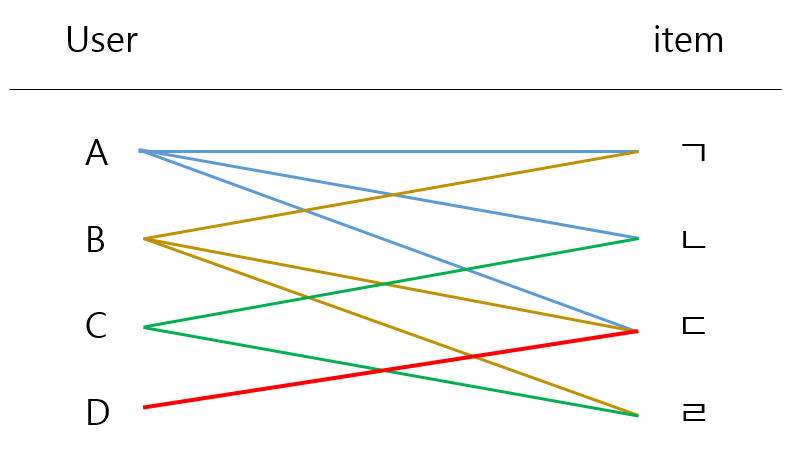

#### 장단점

- 장점: CB, KB의 단점이 없음
- 단점: 새로운 고객과 물건에 대해 대응이 어려움(cold-start issue)

```python
# 출처: movielens

path = 'C:/Users/user/ML/test3'
movies = pd.read_csv(path + '/' + 'movies.csv')
ratings = pd.read_csv(path + '/' + 'ratings.csv')

print(movies.shape)
print(ratings.shape)
```

```
(9742, 3)
(100836, 4)
```

## Business Understanding

- Cross-sell
- Up-sell
- Down-sell

```python
movies.head()
```

|  | movieId | title | genres |
| --- | --- | --- | --- |
| 0 | 1 | Toy Story (1995) | Adventure\|Animation\|Children\|Comedy\|Fantasy |
| 1 | 2 | Jumanji (1995) | Adventure\|Children\|Fantasy |
| 2 | 3 | Grumpier Old Men (1995) | Comedy\|Romance |
| 3 | 4 | Waiting to Exhale (1995) | Comedy\|Drama\|Romance |
| 4 | 5 | Father of the Bride Part II (1995) | Comedy |

```python
ratings.head()
```

|  | userId | movieId | rating | timestamp |
| --- | --- | --- | --- | --- |
| 0 | 1 | 1 | 4.0 | 964982703 |
| 1 | 1 | 3 | 4.0 | 964981247 |
| 2 | 1 | 6 | 4.0 | 964982224 |
| 3 | 1 | 47 | 5.0 | 964983815 |
| 4 | 1 | 50 | 5.0 | 964982931 |

```python
combined = pd.merge(ratings, movies)
combined

# 유저와 아이템 간의 연결관계를 A 유저가 B 아이템에 대해 C 점수를 줬다고 한다면
# A를 index, B를 Column, C를 값으로 표현하는 DataFrame을 만들 수 있음 ->
# 한 Row는 한 유저에 관한 선택 데이터이고,
# 한 Column은 한 물건에 관한 선택 데이터가 되고,
# Row와 Column이 만나는 지점은 A 유저가 B 아이템에 대해 C 점수를 줬다는 것이 됨
```

|  | userId | movieId | rating | timestamp | title | genres |
| --- | --- | --- | --- | --- | --- | --- |
| 0 | 1 | 1 | 4.0 | 964982703 | Toy Story (1995) | Adventure\|Animation\|Children\|Comedy\|Fantasy |
| 1 | 5 | 1 | 4.0 | 847434962 | Toy Story (1995) | Adventure\|Animation\|Children\|Comedy\|Fantasy |
| 2 | 7 | 1 | 4.5 | 1106635946 | Toy Story (1995) | Adventure\|Animation\|Children\|Comedy\|Fantasy |
| 3 | 15 | 1 | 2.5 | 1510577970 | Toy Story (1995) | Adventure\|Animation\|Children\|Comedy\|Fantasy |
| 4 | 17 | 1 | 4.5 | 1305696483 | Toy Story (1995) | Adventure\|Animation\|Children\|Comedy\|Fantasy |
| ... | ... | ... | ... | ... | ... | ... |
| 100831 | 610 | 160341 | 2.5 | 1479545749 | Bloodmoon (1997) | Action\|Thriller |
| 100832 | 610 | 160527 | 4.5 | 1479544998 | Sympathy for the Underdog (1971) | Action\|Crime\|Drama |
| 100833 | 610 | 160836 | 3.0 | 1493844794 | Hazard (2005) | Action\|Drama\|Thriller |
| 100834 | 610 | 163937 | 3.5 | 1493848789 | Blair Witch (2016) | Horror\|Thriller |
| 100835 | 610 | 163981 | 3.5 | 1493850155 | 31 (2016) | Horror |

100836 rows × 6 columns

```python
pvt = combined.pivot_table(index='userId', columns='title', values='rating').fillna(0)
pvt
```

| title userId | '71 (2014) | 'Hellboy': The Seeds of Creation (2004) | 'Round Midnight (1986) | 'Salem's Lot (2004) | 'Til There Was You (1997) | 'Tis the Season for Love (2015) | 'burbs, The (1989) | 'night Mother (1986) | (500) Days of Summer (2009) | *batteries not included (1987) | ... | Zulu (2013) | [REC] (2007) | [REC]² (2009) | [REC]³ 3 Génesis (2012) | anohana: The Flower We Saw That Day - The Movie (2013) | eXistenZ (1999) | xXx (2002) | xXx: State of the Union (2005) | ¡Three Amigos! (1986) | À nous la liberté (Freedom for Us) (1931) |
| --- | --- | --- | --- | --- | --- | --- | --- | --- | --- | --- | --- | --- | --- | --- | --- | --- | --- | --- | --- | --- | --- |
| 1 | 0.0 | 0.0 | 0.0 | 0.0 | 0.0 | 0.0 | 0.0 | 0.0 | 0.0 | 0.0 | ... | 0.0 | 0.0 | 0.0 | 0.0 | 0.0 | 0.0 | 0.0 | 0.0 | 4.0 | 0.0 |
| 2 | 0.0 | 0.0 | 0.0 | 0.0 | 0.0 | 0.0 | 0.0 | 0.0 | 0.0 | 0.0 | ... | 0.0 | 0.0 | 0.0 | 0.0 | 0.0 | 0.0 | 0.0 | 0.0 | 0.0 | 0.0 |
| 3 | 0.0 | 0.0 | 0.0 | 0.0 | 0.0 | 0.0 | 0.0 | 0.0 | 0.0 | 0.0 | ... | 0.0 | 0.0 | 0.0 | 0.0 | 0.0 | 0.0 | 0.0 | 0.0 | 0.0 | 0.0 |
| 4 | 0.0 | 0.0 | 0.0 | 0.0 | 0.0 | 0.0 | 0.0 | 0.0 | 0.0 | 0.0 | ... | 0.0 | 0.0 | 0.0 | 0.0 | 0.0 | 0.0 | 0.0 | 0.0 | 0.0 | 0.0 |
| 5 | 0.0 | 0.0 | 0.0 | 0.0 | 0.0 | 0.0 | 0.0 | 0.0 | 0.0 | 0.0 | ... | 0.0 | 0.0 | 0.0 | 0.0 | 0.0 | 0.0 | 0.0 | 0.0 | 0.0 | 0.0 |
| ... | ... | ... | ... | ... | ... | ... | ... | ... | ... | ... | ... | ... | ... | ... | ... | ... | ... | ... | ... | ... | ... |
| 606 | 0.0 | 0.0 | 0.0 | 0.0 | 0.0 | 0.0 | 0.0 | 0.0 | 0.0 | 0.0 | ... | 0.0 | 0.0 | 0.0 | 0.0 | 0.0 | 0.0 | 0.0 | 0.0 | 0.0 | 0.0 |
| 607 | 0.0 | 0.0 | 0.0 | 0.0 | 0.0 | 0.0 | 0.0 | 0.0 | 0.0 | 0.0 | ... | 0.0 | 0.0 | 0.0 | 0.0 | 0.0 | 0.0 | 0.0 | 0.0 | 0.0 | 0.0 |
| 608 | 0.0 | 0.0 | 0.0 | 0.0 | 0.0 | 0.0 | 0.0 | 0.0 | 0.0 | 0.0 | ... | 0.0 | 0.0 | 0.0 | 0.0 | 0.0 | 4.5 | 3.5 | 0.0 | 0.0 | 0.0 |
| 609 | 0.0 | 0.0 | 0.0 | 0.0 | 0.0 | 0.0 | 0.0 | 0.0 | 0.0 | 0.0 | ... | 0.0 | 0.0 | 0.0 | 0.0 | 0.0 | 0.0 | 0.0 | 0.0 | 0.0 | 0.0 |
| 610 | 4.0 | 0.0 | 0.0 | 0.0 | 0.0 | 0.0 | 0.0 | 0.0 | 3.5 | 0.0 | ... | 0.0 | 4.0 | 3.5 | 3.0 | 0.0 | 0.0 | 2.0 | 1.5 | 0.0 | 0.0 |

610 rows × 9719 columns